# CountingRationalsWithStern-BrocotAndCalkin-WilfTrees

```python
import numpy as np
from typing import Any, List, Union, Optional, Tuple, Callable
from fractions import Fraction
from math import *
import matplotlib.pyplot as plt
from itertools import product
```

### Binary tree

#### Levels

In the following we'll represent the `m` first successive levels of a binary tree by a list of `m` lists each one of $1,2,\cdots,2^{m-1}$ nodes representing at level $0$ the root, at level $1$ the left and right sons of the root, and at the level $k+1$ the left and right sons of the $i^{th}$ node of the level $k$ by respectively the nodes with respective indices $2i$ and $2i+1$ of this level $k+1$ where $i \in \{0,1,\ldots,k-1\}$.  
Below a function `bin_levels(lst)` that transforms a list `lst` in the levels of the corresponding binary tree.

```python
def bin_levels(lst: List[Any]) -> List[List[Any]]:
    """ divide a list in blocks (lists) corresponding to the first levels of a binary tree

    Args:
        lst:  a list
    Returns:
        a list of levels: [lvls[0],...,lvls[k],..., lvls[-1]]]
        length(lvls[0]) == 1, lvls[0][0] is the root of the binary tree
        for each level k > 0, len(lvls[k]) == 2*len(lvls[k-1]),
        but for the last level, len(lvls[-1]) <= 2*len(lvls[-2]) depending on len(lst)
    Example:
        if lst = [1, 2, 3, 4, 5, 6, 7, 8, 9, 10, 11, 12, 13, 14, 15]
        bin_levels(lst) -> [[1], [2, 3], [4, 5, 6, 7], [8, 9, 10, 11, 12, 13, 14, 15]]
    """
    n = len(lst)
    lvls = []
    m = 1
    while 2*m <= n:
        lvls.append(lst[m-1:2*m-1])
        m = 2*m
    lvls.append(lst[m-1:n+1])
    return lvls
```

```python
l13 = list(range(1,14))
print('l13 = {}'.format(l13))
print('levels:             0    1       2             3')
print('bin_levels(l13):  {}'.format(bin_levels(l13)))
```

```
l13 = [1, 2, 3, 4, 5, 6, 7, 8, 9, 10, 11, 12, 13]
levels:             0    1       2             3
bin_levels(l13):  [[1], [2, 3], [4, 5, 6, 7], [8, 9, 10, 11, 12, 13]]
```

And `print_bintree(levels)` is a pretty print for binary trees expressed in this form

```python
def print_bintree(lvls : List[List[Any]],r: int = 1, fmt: Callable[[Any],str] = str) -> None:
    """ pretty print of a binary tree defined by lvls as in the result
        of the bin_levels function

    Args:
        lvls: binary tree as a list of levels: [lvls[0],...,lvls[k],..., lvls[-1]]]
              length(lvls[0]) == 1, lvls[0][0] is the root of the binary tree
              for each level k > 0, len(lvls[k]) == 2*len(lvls[k-1]),
              but for the last level, len(lvls[-1]) <= 2*len(lvls[-2])
        r:    (int) w = 2*r+1 is the width of printed label for each node.
              default: r=1 => 3 characters for each node's label
        fmt:  a function defining the print format of each node.
              default: the function str
    Returns:
        None: this function is just for printing the first levels of a binary tree
    """
    def bn(klvl: int, r: int, n: int) -> int:
        """returns the half-distance between two nodes at level klvl

        Args:
            klvl: (int) the level number
            r:    (int) w = 2*r+1 is the width of label for each node
            n:    number of levels
        Returns:
            (int) the half-distance between two nodes at level klvl
        """
        return (2*r+1)*(2**(n-1-klvl)-1)
    n = len(lvls)
    # lbn: list of the half-distance lbn[k] between two nodes at each level k
    lbn = [bn(k,r,n) for k in range(n)]
    # lu[k]: length of horizontal branches in level k
    lu = [el//2 for el in lbn]
    # w: number of chars for each node
    w = 2*r+1
    for k in range(n):
        print(''.join([(lbn[k]+r)*' ' + '|' + (lbn[k]+3*r+1)*' ' for el in lvls[k]]))
        print(''.join([(lu[k]+(k!=(n-1)))*' ' + lu[k]*'_' + '{:^{}}'.format(fmt(el),w) +
                       lu[k]*'_'+ (lu[k]+(k!=(n-1))+2*r+1)*' ' for el in lvls[k]]))
```

```python
print_bintree(bin_levels(l13))
```

```
           __________ 1 __________
          |                       |
     ____ 2 ____             ____ 3 ____
    |           |           |           |
  _ 4 _       _ 5 _       _ 6 _       _ 7 _
 |     |     |     |     |     |
 8     9    10    11    12    13
```

#### Path string

Let's use the letters L and R to stand for going down to the left or right branch as we proceed from the root of a binary tree to a particular node; then a string of L's and R's uniquely identifies a place in the tree. For example in the tree above, to reach the node with label 12, from the root 1 we are going right to 3, left to 6 and left to 12. The node with label 12 can be adressed by the "path string" `'RLL'`.  
The function `paths_level(k)` returns the "path strings" ordered list describing all the nodes the $k^{th}$ level of a binary tree:

- `['']` for the root at level k = 0
- `['L', 'R']` for the left and right sons of the root at the first level k = 1
- `['LL', 'LR', 'RL', 'RR']` at level k = 2, for the respective left and right sons of level 1 nodes and so on ...

```python
def paths_level(k: int) -> List[str]:
    """ return the path strings describing the kth level of a binary tree:

    Args:
        k: an integer
    Returns:
        a list of strings, defining the ordered list of the level's nodes
    Examples:
        [''] for the root at level k = 0
        ['L', 'R'] for the left and right sons of the root at the first level k = 1,
        ['LL', 'LR', 'RL', 'RR'] at level k = 2 for the respective left and right sons of level 1 nodes
        """
    return [''.join(t) for t in product(('L','R'),repeat=k)]
```

```python
print(paths_level(3))
```

```
['LLL', 'LLR', 'LRL', 'LRR', 'RLL', 'RLR', 'RRL', 'RRR']
```

#### Bits representation

```python
def ints2bin(ints: List[int], nbits: Optional[int] = None) -> List[str]:
    """ return the list of the binary representations on nbits of all integers in the list ints.

    Args:
        ints: a list of integers
        nbits: an integer, the fixed length for all the bits string representing the integers in ints.
        If nbits == None then for each integer in ints the binary representation is the string of minimal length
    Returns:
        The list of the binary representation of the integers in ints
    Example:
        ints2bin([1,2],nbits=3) ->  ['001', '010']
        ints2bin([1,2]) ->  ['1', '10']
    """
    return [np.binary_repr(k,nbits) for k in ints]

def rev_ints(ints: List[int], nbits: Optional[int] = None) -> List[int]:
    """return the list of integers resulting of the reversing of the binary repr of the integers in  ints

    Args:
        ints: a list of integers
        nbits: an integer, the fixed length for all the bits string representing the integers in ints.
        If nbits == None then for each integer in ints the binary representation is the string of minimal length
    Returns:
        the list of integers resulting of the reversing of the binary repr of the integers in  ints
    Example:
        rev_ints([1,2],nbits=3) -> [4, 2] (['001', '010'] -> ['100', '010'])
        rev_ints([1,2]) -> [1, 1] (['1', '10'] -> ['1', '1'])
    """
    return [int(bits[::-1],2) for bits in ints2bin(ints,nbits)]

def str_translate(s: str, fromchrs: str = '01', tochrs: str = '10') -> str:
    """substitute in the string s the characters in fromchrs to those in tochrs and return the resulting string

    Args:
        s: a string
        fromchrs: a string listing all the characters to be changed
        tochrs: a string listing the corresponding substitutes
    Returns:
        the string resulting from the substitutions in s.
    Examples:
       str_transl('1101') -> '0010'
       str_transl('LLRL','LR','01') -> '0010'
    """
    if s == '':
        return tochrs[0]
    return s.translate(dict(list(zip((map(ord,fromchrs)),tochrs))))
```

With the substitutions: `L -> 0` and `R -> 1`, we substitute the the path string indexation of a node for the numerical index of this node in the corresponding level:  
For example the node with path string `'RRL'` is the node number `6` of level 3 (`len('RRL')`)  
because `str_translate('RRL','LR','01')` is `'110'` and `int('110',2)` is `6`. Remember that node number `6` is the $7^{th}$ node, the Python indexation beginning with`0`.  
We define two functions to pass from one indexation to the other: `level_idx(path_string)` and `path_str(level,idx)`

```python
def level_idx(path_string: str) -> Tuple[int, int]:
    """ returns a pair of integers(level_number,idx) identifying the positition
        idx of a node in the list representing the level in a binary tree.

    Args:
        path_string: a string of 'L' and 'R',describing the left and right from the root moves to reach a node
    Returns:
        a tuple of 2 integers: the node's level number and his index position in the corresponding list
    Example:
        level_idx('RRL') -> (3, 6)
        """
    return len(path_string), int(str_translate(path_string,'LR','01'), 2)
```

```python
level_idx('RRL')
```

```
(3, 6)
```

```python
def path_str(level: int, idx: int) -> str:
    """ returns the path string of the node defined by level and idx

    Args:
        level: (int) node's level number of the node the pair of integers(level,idx) identifies the positition idx of a node
        idx: (int) node's index in the list representing the level
    Returns:
        the node's corresponding path string
    Example:
        path_str(3,6) == 'RRL'
    """
    return str_translate(np.binary_repr(idx,level),'01','LR')
```

```python
path_str(3,6)
```

```
'RRL'
```

These functions are inverses of each other:

```python
level_idx(path_str(*(3,6))) == (3,6) and path_str(*level_idx('RRL')) == 'RRL'
```

```
True
```

If we do the same substitution on all the path strings of a level as given for example by `paths_level(3)` we obtain obviously the list of the first $2^3 = 8$ consecutives integers:

```python
paths_lvl3 = paths_level(3)
print(paths_lvl3)
print([str_translate(s,'LR','01') for s in paths_lvl3])
print([level_idx(s)[1] for s in paths_lvl3])
```

```
['LLL', 'LLR', 'LRL', 'LRR', 'RLL', 'RLR', 'RRL', 'RRR']
['000', '001', '010', '011', '100', '101', '110', '111']
[0, 1, 2, 3, 4, 5, 6, 7]
```

### Stern Brocot Tree

The following text cells are a transcription of the chapter on Stern-Brocot tree in the Donald Knuth's book *Concrete Mathematics* (p.129) and the Python cells a programming materialization of this chapter.

#### There's a beautiful way to construct the set of all nonnegative fractions m/n with m ⊥ n , called the Stern-Brocot tree.

Using the Donald Knuth's notation we'll write $m \perp n$ for a pair of two integers $m,n$ who are relatively prime (coprime). A fraction $m/n$ is in lowest terms if and only if $m \perp n$ .

The idea is to start with the two fractions (0/1, 1/0) (here we add 1/0 for $\infty$!) and then to repeat the following operation as many times as desired:  
Insert (m + m')/(n + n') between two adjacent fractions m/n and m'/n'.  
The new fraction **(m+m')/(n+n')** is called the **mediant** of **m/n** and **m'/n'**.  
The first step gives us one new entry 1/1, the next two more, 1/2 between 0/1 and 1/1, and 2/1 between 1/1 and 1/0 and so on, building a binary tree with root 1/1.

To build this construct we'll first examine a way to produce the tree corresponding to the numerators of these nonnegative fractions.  
We'll start with the integers(0,1) and then we repeat the following operation as many times as desired, i.e depending on the level desired:  
Insert m + m' between two adjacent integers m and m'.  
Build each level successively and in the same time keep a kind of "cumulative" list:  
level 0: `[0+1] = [1]`  
cumul: `[1]` level 1: `[0+1,1+1] = [1,2]`  
cumul:`[1,1,2]`  
level 2: `[0+1,1+1,1+2,2+1] = [1,2,3,3]` etc...  
This construction is defined from different sources:

#### Stern (diatomique) sequence

can be defined by $$s(0) = 0,\ s(1) = 1 \ \textrm{and} \ \ s(2n) = s(n),\ s(2n + 1) = s(n) + s(n + 1)\ \textrm{when} \ (n ≥ 1)$$ This sequence, which appears in different notations in the literature, is sequence A002487 in [*The On-Line Encyclopedia of Integer Sequences*](http://oeis.org), where numerous properties and references can be found. The first few nonzero terms of the sequence (1) are easily seen to be **1**, **1**, 2, **1**, 3, 2, 3, **1**, 4, 3, 5, 2, 5, 3, 4, **1**, 5,. . . , where those with an index that is a power of 2 are shown in bold.
See also [Rational Trees and Binary Partitions](http://www.luschny.de/math/seq/RationalTreesAndBinaryPartitions.html) from Peter Luschny, March 2010.
The next function is a free adaptation in Python from a maple program adapted from E. Dijkstra, Selected Writings on Computing, Springer, 1982, p. 232.

```python
def stern_levels(m: int, a: int = 0, b: int = 1) -> Tuple[List[List[int]], List[int]]:
    """ This function build the first m levels of the numerators of the Stern-Brocot binary tree
        and the list of the first 2**m-1 terms of the Stern sequence

    Args:
        m: (int) the desired number of levels for the Stern-Brocot binary tree
        a: (int) first initial value
        b: (int) second initial value
    Returns: a tuple t = (levels, l)
        t[0]: levels, a m terms list where levels[k] is a list of 2**k integers,
              a representation of the tree of the numerators of kth level in the Stern-Brocot tree.
        t[1]: list of the first 2**m-1 terms of the Stern sequence
    """
    l = [a,b]
    levels = []
    for k in range(1,m+1):
        l_k = [l[0]]
        level_k = []
        for i in range(len(l)-1):
            si = l[i]+l[i+1]
            level_k.append(si)
            l_k.append(si)
            l_k.append(l[i+1])
        levels.append(level_k)
        l = l_k[:]
    return levels,l[1:-1]
```

```python
SBnums_5,stern_list_5 = stern_levels(5)
```

```python
for l in SBnums_5:
    print(l)
```

```
[1]
[1, 2]
[1, 2, 3, 3]
[1, 2, 3, 3, 4, 5, 5, 4]
[1, 2, 3, 3, 4, 5, 5, 4, 5, 7, 8, 7, 7, 8, 7, 5]
```

This first result give the five first levels of the numerators tree:

```python
print_bintree(SBnums_5)
```

```
                       ______________________ 1 ______________________
                      |                                               |
           __________ 1 __________                         __________ 2 __________
          |                       |                       |                       |
     ____ 1 ____             ____ 2 ____             ____ 3 ____             ____ 3 ____
    |           |           |           |           |           |           |           |
  _ 1 _       _ 2 _       _ 3 _       _ 3 _       _ 4 _       _ 5 _       _ 5 _       _ 4 _
 |     |     |     |     |     |     |     |     |     |     |     |     |     |     |     |
 1     2     3     3     4     5     5     4     5     7     8     7     7     8     7     5
```

```python
print(stern_list_5)
```

```
[1, 1, 2, 1, 3, 2, 3, 1, 4, 3, 5, 2, 5, 3, 4, 1, 5, 4, 7, 3, 8, 5, 7, 2, 7, 5, 8, 3, 7, 4, 5]
```

And we'll note that this second result `stern_levels(5)[1]`, is the "ordered projection" on a line of all the nodes of the 5-levels tree

We'll note than the denominators will be obtained in the same way starting with the integers (1,0), using the the same function `stern_levels(m,1,0)` or reversing each list in the first result of `SBnums(m,0,1)`

```python
SBdens_5, _ = stern_levels(5,1,0)
```

```python
for l in SBdens_5:
    print(l)
```

```
[1]
[2, 1]
[3, 3, 2, 1]
[4, 5, 5, 4, 3, 3, 2, 1]
[5, 7, 8, 7, 7, 8, 7, 5, 4, 5, 5, 4, 3, 3, 2, 1]
```

or using the `Python` notation to get the reversed `l[::-1]` of a list `l`

```python
SBdens_5 = [l[::-1] for l in SBnums_5]
```

```python
for l in SBdens_5:
    print(l)
```

```
[1]
[2, 1]
[3, 3, 2, 1]
[4, 5, 5, 4, 3, 3, 2, 1]
[5, 7, 8, 7, 7, 8, 7, 5, 4, 5, 5, 4, 3, 3, 2, 1]
```

And for each level we can build the nodes list, each node as a pair `(numerator,denominator)`.  
For example the nodes of level 3:

```python
i=3
print(list(zip(SBnums_5[i],SBdens_5[i])))
```

```
[(1, 4), (2, 5), (3, 5), (3, 4), (4, 3), (5, 3), (5, 2), (4, 1)]
```

Or as a list of the corresponding fractions:

```python
i=3
print([str(Fraction(*pair)) for pair in zip(SBnums_5[i],SBdens_5[i])])
```

```
['1/4', '2/5', '3/5', '3/4', '4/3', '5/3', '5/2', '4']
```

In this way we can build the Stern-Brocot tree up to a desired level `m`.

```python
def SBpairs(m: int) -> List[List[Tuple[int, int]]]:
    """ return the first m levels of Stern-Brocot tree, the nodes being a pair (numerator,denominator)

    Args:
        m: (int) the desired number of levels for the Stern-Brocot binary tree
    Returns:
        the first m levels of Stern-Brocot tree, with the pairs (numerator, denominator) as nodes
    """
    sbnums_m, _ = stern_levels(m,0,1)
    sbdens_m, _ = stern_levels(m,1,0)
    return [list(zip(sbnums_m[k],sbdens_m[k])) for k in range(m)]
```

```python
for l in SBpairs(5):
    print(l)
```

```
[(1, 1)]
[(1, 2), (2, 1)]
[(1, 3), (2, 3), (3, 2), (3, 1)]
[(1, 4), (2, 5), (3, 5), (3, 4), (4, 3), (5, 3), (5, 2), (4, 1)]
[(1, 5), (2, 7), (3, 8), (3, 7), (4, 7), (5, 8), (5, 7), (4, 5), (5, 4), (7, 5), (8, 5), (7, 4), (7, 3), (8, 3), (7, 2), (5, 1)]
```

```python
print_bintree(SBpairs(5),fmt=lambda pair:'{},{}'.format(*pair))
```

```
                       ______________________1,1______________________
                      |                                               |
           __________1,2__________                         __________2,1__________
          |                       |                       |                       |
     ____1,3____             ____2,3____             ____3,2____             ____3,1____
    |           |           |           |           |           |           |           |
  _1,4_       _2,5_       _3,5_       _3,4_       _4,3_       _5,3_       _5,2_       _4,1_
 |     |     |     |     |     |     |     |     |     |     |     |     |     |     |     |
1,5   2,7   3,8   3,7   4,7   5,8   5,7   4,5   5,4   7,5   8,5   7,4   7,3   8,3   7,2   5,1
```

```python
print_bintree(SBpairs(5),fmt=lambda pair:str(Fraction(*pair)))
```

```
                       ______________________ 1 ______________________
                      |                                               |
           __________1/2__________                         __________ 2 __________
          |                       |                       |                       |
     ____1/3____             ____2/3____             ____3/2____             ____ 3 ____
    |           |           |           |           |           |           |           |
  _1/4_       _2/5_       _3/5_       _3/4_       _4/3_       _5/3_       _5/2_       _ 4 _
 |     |     |     |     |     |     |     |     |     |     |     |     |     |     |     |
1/5   2/7   3/8   3/7   4/7   5/8   5/7   4/5   5/4   7/5   8/5   7/4   7/3   8/3   7/2    5
```

And if we combine the second results `stern_levels(m,a=0,b=1)[1]` and `stern_levels(m,a=1,b=0)[1]` we'll get the "projection", as an ordered sequence of all the fractions of the `m` levels tree just above.

```python
m=5
for frac in [Fraction(*pair) for pair in zip(stern_levels(m,a=0,b=1)[1],stern_levels(m,a=1,b=0)[1])]:
    print(frac,end=' ')
```

```
1/5 1/4 2/7 1/3 3/8 2/5 3/7 1/2 4/7 3/5 5/8 2/3 5/7 3/4 4/5 1 5/4 4/3 7/5 3/2 8/5 5/3 7/4 2 7/3 5/2 8/3 3 7/2 4 5
```

#### the fundamental fact:

If $m/n < m'/n'$ are consecutive fractions at any stage of the construction, we have: $m'n − mn' = 1$  
By Bezout identity, it means that $m,n$ are relatively prime (or coprime) and the same for the pair $m',n'$. Using the Donald Knuth's notation we'll write $m \perp n$ for such a pair. A fraction $m/n$ is in lowest terms if and only if $m \perp n$.

1. It's true for $0/1$ and $1/0$ for $( 1 · 1 − 0 · 0 = 1 )$. Note that we accept $1/0$ for $\infty$ but we are reasoning on the pair `(1,0)`...
2. when we insert a new mediant $(m + m')/(n + n')$ , the new cases that need to be checked are:
   $$(m + m')n − m(n + n') = 1 $$ $$m'(n + n') − (m + m')n' = 1$$ Both of these equations are equivalent to the original condition.
   So $m \perp n$, $m' \perp n'$ and we have the same for the mediant $(m + m') \perp (n + n')$
3. Furthermore as the integers are non negatives and as $$m'n − mn' = 1 \Leftrightarrow \frac{m'}{n'} − \frac{m}{n} = \frac{1}{nn'}$$
   we have $$\frac{m}{n} < \frac{m + m'}{n + n'} < \frac{m'}{n'}$$ Therefore the construction preserves order, explaining why the "projection" above is an ordered sequence of the considered fractions and we couldn't possibly get the same fraction in two different places.
4. One question still remains. Can any positive fraction $a/b$ with $a ⊥ b$ possibly be omitted? The answer is no, because we can confine the construction to the immediate neighborhood of $a/b$ , and in this region the behavior is easy to analyze: Initially we have: $$\frac{m}{n} = \frac{0}{1} \ < \ (\frac{a}{b}) \ < \ \frac{1}{0} = \frac{m'}{n'}$$ where we put parentheses around $a/b$ to indicate that it's not really present yet. Then if at some stage we have $$\frac{m}{n} \ < \ (\frac{a}{b}) \ < \ \frac{m'}{n'}$$ the construction forms $(m + m')/(n + n')$ and there are three cases. Either $(m + m' )/(n + n') = a/b$ and we win; or $(m + m')/(n + n') < a/b$ and we can set $m ← m + m' , n ← n + n'$ ; or $(m + m')/(n + n') > a/b$ and we can set $m' ← m + m' , n' ← n + n'$ . This process cannot go on indefinitely, because the conditions: $$ \frac{a}{b} - \frac{m}{n} > 0 \quad \textrm{ and } \quad \frac{m'}{n'} - \frac{a}{b} > 0 $$ imply that $$ an − bm \ \geq \ 1 \quad \textrm{ and } \quad bm' − an' \ \geq \ 1 $$ Hence $$ (m' + n')(an − bm) + (m + n)(bm' − an') \ \geq \ m' + n'+ m + n $$ and this is the same than:
   $$ a + b \ \geq \ m' + n'+ m + n$$ Either $m$ or $n$ or $m'$ or $n'$ increases at each step, so we must win after at most $a + b$ steps.
   Conclusion: **The nodes of the Stern-Brocot tree are all the nonnegative fractions m/n with m ⊥ n.**

### Calkin-Wilf tree

In an article named [*Recounting the rationals*](https://fermatslibrary.com/s/recounting-the-rationals#email-newsletter) Neil Calkin and Herbert S. Wilf give another tree representation of the rationals using the **Stern (diatomic) sequence**
this sequence can be defined by $$s(0) = 0,\ s(1) = 1 \ \textrm{and} \ \ s(2n) = s(n),\ s(2n + 1) = s(n) + s(n + 1)\ \textrm{when} \ (n ≥ 1)$$. This sequence, which appears in different notations in the literature, is sequence A002487 in [*The On-Line Encyclopedia of Integer Sequences*](http://oeis.org/A002487), where numerous properties and references can be found. The first few nonzero terms of the sequence (1) are easily seen to be **1**, **1**, 2, **1**, 3, 2, 3, **1**, 4, 3, 5, 2, 5, 3, 4, **1**, 5,. . . , where those with an index that is a power of 2 are shown in bold. [Rational Trees and Binary Partitions](http://www.luschny.de/math/seq/RationalTreesAndBinaryPartitions.html) from Peter Luschny, March 2010.
But the second result of `stern_levels(m)` is just the list of the first $2^m-1$ terms of this sequence (without the leading 0) and represents the first $2^m-1$ numerators of the Calkin-Wilf representation according to their article. For example for $m = 5$:

```python
stern_list_5 = stern_levels(5)[1]
print(stern_list_5)
```

```
[1, 1, 2, 1, 3, 2, 3, 1, 4, 3, 5, 2, 5, 3, 4, 1, 5, 4, 7, 3, 8, 5, 7, 2, 7, 5, 8, 3, 7, 4, 5]
```

If we build a binary tree from this sequence we get the binary tree of the numerators of the Calkin-Wilf tree

```python
print_bintree(bin_levels(stern_list_5))
```

```
                       ______________________ 1 ______________________
                      |                                               |
           __________ 1 __________                         __________ 2 __________
          |                       |                       |                       |
     ____ 1 ____             ____ 3 ____             ____ 2 ____             ____ 3 ____
    |           |           |           |           |           |           |           |
  _ 1 _       _ 4 _       _ 3 _       _ 5 _       _ 2 _       _ 5 _       _ 3 _       _ 4 _
 |     |     |     |     |     |     |     |     |     |     |     |     |     |     |     |
 1     5     4     7     3     8     5     7     2     7     5     8     3     7     4     5
```

and according to the same article the corresponding denominators list is:

```python
print(stern_list_5[1:]+[1])
```

```
[1, 2, 1, 3, 2, 3, 1, 4, 3, 5, 2, 5, 3, 4, 1, 5, 4, 7, 3, 8, 5, 7, 2, 7, 5, 8, 3, 7, 4, 5, 1]
```

And as described in the same article [*Recounting the rationals*](https://fermatslibrary.com/s/recounting-the-rationals#email-newsletter) we can build Calkin-Wilf tree representing all the rationals. More exactly we build a new function `CWpairs(m)` returning the first $m$ levels with the first $2^m - 1$ nodes of this tree

```python
def CWpairs(m):
    """ return the first m levels of Calkin-Wilf tree, the nodes being a pair (numerator,denominator)

    Args:
        m: (int) the desired number of levels for the Calkin-Wilf binary tree
    Returns:
        the first m levels of Calkin-Wilf tree, with the pairs (numerator, denominator) as nodes
    """
    nums = stern_levels(m)[1]
    dens = nums[1:]+[1]
    return bin_levels(list(zip(nums,dens)))
```

```python
print_bintree(CWpairs(5),fmt=lambda pair:'{},{}'.format(*pair))
```

```
                       ______________________1,1______________________
                      |                                               |
           __________1,2__________                         __________2,1__________
          |                       |                       |                       |
     ____1,3____             ____3,2____             ____2,3____             ____3,1____
    |           |           |           |           |           |           |           |
  _1,4_       _4,3_       _3,5_       _5,2_       _2,5_       _5,3_       _3,4_       _4,1_
 |     |     |     |     |     |     |     |     |     |     |     |     |     |     |     |
1,5   5,4   4,7   7,3   3,8   8,5   5,7   7,2   2,7   7,5   5,8   8,3   3,7   7,4   4,5   5,1
```

```python
print_bintree(CWpairs(5),fmt=lambda pair:str(Fraction(*pair)))
```

```
                       ______________________ 1 ______________________
                      |                                               |
           __________1/2__________                         __________ 2 __________
          |                       |                       |                       |
     ____1/3____             ____3/2____             ____2/3____             ____ 3 ____
    |           |           |           |           |           |           |           |
  _1/4_       _4/3_       _3/5_       _5/2_       _2/5_       _5/3_       _3/4_       _ 4 _
 |     |     |     |     |     |     |     |     |     |     |     |     |     |     |     |
1/5   5/4   4/7   7/3   3/8   8/5   5/7   7/2   2/7   7/5   5/8   8/3   3/7   7/4   4/5    5
```

**We remark that for each `m` the Stern-Brocot tree and the Calkin-Wilf tree, up to level `m` contain the same fractions, because, for every `0<k<m` the levels `SBpairs(m)[k]` and `CWpairs(m)[k]` contain two different permutations of the same pairs, all issued from the same sequence `stern_levels(m)[1]`.**  
as we saw before with `m = 5`.

```python
print(stern_levels(5)[1])
```

```
[1, 1, 2, 1, 3, 2, 3, 1, 4, 3, 5, 2, 5, 3, 4, 1, 5, 4, 7, 3, 8, 5, 7, 2, 7, 5, 8, 3, 7, 4, 5]
```

### Stern-Brocot tree or Calkin-Wilf tree as number system for representing rational numbers

As we presented in the chapter on **Binary Trees** we can use use the letters L and R for going down to the left or right branch as we proceed from the root of a tree to a particular fraction and a string of L's and R's uniquely identifies a place in the tree.  
In the Stern-Brocot tree, for example, LRLL means that we go left from 1/1 down to 1/2 , then right to 2/3 , then left to 3/5 , then left to 4/7 .  
In this tree we can consider LRLL to be a representation of 4/7 . Every positive fraction gets represented in this way as a unique string of L's and R's.  
Well, actually there's a slight problem: The fraction 1/1 corresponds to the empty string, and we need a notation for that. Let's agree to call it I , because that looks something like 1 and it stands for "identity." This representation raises two natural questions:

1. Given positive integers $m$ and $n$ with $m \perp n$ , what is the string of L's and R's that corresponds to $m/n$ ?
2. Given a string of L's and R's, what fraction corresponds to it?  
   Question 2 seems easier, so let's work on it first. For Stern-Brocot the we define:  
   `SBfrac(S) =` the fraction corresponding to the path string `S`in this tree.  
   For example, `SBfrac('LRLL') == Fraction(4,7)` .  
   And we do the same for the Calkin-Wilf tree: We define  
   `CWfrac(S) =` the fraction corresponding to the path string `S`in the Calkin-Wilf tree. In this case `CWfrac('LRLL') == Fraction(3,8)`.

#### Matrix representation

We define some functions using `numpy arrays` for 2x2 matrices corresponding  
to strings composed of chars in 'ILR' describing pathes in a binary string:  
''→ I, 'I' → I, 'L' → L, 'R' → R  
and a string, sequence of 'L' and 'R' by the product M of the corresponding matrices L and R  
`powmat(M,n)` for $M^n$ where $M$ is a matrix  
`matprod(mats)` for the matrix product $M_0 M_1 \cdots M_n$ if $\textrm{mats} = [M_0, M_1, \cdots, M_n]$ where, for $0 \leq i \leq n$, $M_i$ is L or R.  
`path2mat(S)` for the matrix product of the elementary matrices L,R present in a binary string S node's path

```python
""" Specific 2x2 matrices in the Stern-Brocot context"""
L = np.array([[1,1],[0,1]])  # left move, left root's son
R = np.array([[1,0],[1,1]])  # right move, right root's son
I = np.eye(2,dtype=int)      #identity, root

def powmat(M: np.array, n: int) -> np.array:
    """ return the n-th power of a matrix M

    Args:
        M: (np.array) a square matrix pxp
        n: (int) exponent
    Returns:
        the n-th power of M
    """
    assert n >= 0, "{} is not a positive or null integer".format(n)
    if n == 0:
        return np.eye(M.shape[0],dtype=int)
    return M @ powmat(M,n-1)

def matprod(mats: List[np.array], n: int = 2)-> np.array:
    """ mats is a list of matrices pxp. By defaut n == 2

    Args:
        mats: a list of square matrices pxp
    Returns:
        the matrix (np.array) product of all the matrices in the list in the same order
    """
    if len(mats) == 0:
        return np.eye(n,dtype=int)
    if len(mats) == 1:
        return mats[0]
    return mats[0] @ matprod(mats[1:])

def path2mat(S: str) -> np.array:
    """return the matrix product corresponding to a path string in a Stern-Brocot binary tree

    Args:
        S: (str) a node's path string
    Returns:
        the corresponding product matrix (np.array)
    """
    return matprod([eval(chr) for chr in S])

print('I = ')
print(I)
print('L = ')
print(L)
print('R = ')
print(R)
```

```
I =
[[1 0]
 [0 1]]
L =
[[1 1]
 [0 1]]
R =
[[1 0]
 [1 1]]
```

```python
powmat(L,0)
```

```
array([[1, 0],
       [0, 1]])
```

```python
L@L@L
```

```
array([[1, 3],
       [0, 1]])
```

```python
path2mat('')
```

```
array([[1, 0],
       [0, 1]])
```

```python
path2mat('LRLL')
```

```
array([[2, 5],
       [1, 3]])
```

```python
M = L@R@L@L
print(M)
```

```
[[2 5]
 [1 3]]
```

In the Stern-Brocot tree we'll note that the fraction $\dfrac{n}{d}$ is represented by the vector $[d,n]$. In this form the node left to $\dfrac{1}{2}$ is the node $\dfrac{1}{3}$ described by the vector `L@[2,1] = [3 1]` and the node right to $\dfrac{1}{2}$ is the node described by the vector `R@[2,1] = [2 3]` for the fraction $\dfrac{3}{2}$

and the product $\begin{equation*} LRLL\begin{bmatrix} 1 \\ 1 \end{bmatrix}=\begin{bmatrix} 2 & 5 \\ 1 & 3 \end{bmatrix} \begin{bmatrix} 1 \\ 1 \end{bmatrix} = \begin{bmatrix} 7 \\ 4 \end{bmatrix} \end{equation*}$ represents the fraction $\dfrac{4}{7}$.

```python
print(M@[1,1])
```

```
[7 4]
```

**Calkin-Wilf tree matrix representation**  
If we consider a Calkin-Wilf tree's node $\dfrac{n}{d}$ represented by the line vector $\begin{bmatrix}n & d\end{bmatrix}$  
The product $\begin{equation*}\begin{bmatrix}n & d\end{bmatrix}L = \begin{bmatrix}n & d\end{bmatrix}\begin{bmatrix} 1 & 1 \\ 0 & 1 \end{bmatrix} = \begin{bmatrix}n & n + d\end{bmatrix}\end{equation*}$ represents the node $\dfrac{n}{n+d}$  
The product $\begin{equation*}\begin{bmatrix}n & d\end{bmatrix}R = \begin{bmatrix}n & d\end{bmatrix}\begin{bmatrix} 1 & 0 \\ 1 & 1 \end{bmatrix} = \begin{bmatrix}n + d & d \end{bmatrix}\end{equation*}$ represents the node $\dfrac{n+d}{d}$  
These are exactly the rules of construction of the Calkin-Wilf tree. In this way the same matrix $M$ representing a path $S$ in the Stern-Brocot tree give the value of a node in the Calkin-Wilf tree.  
With the same matrix product M = LRLL we get the fraction $\dfrac{3}{8}$ in the Calkin-Wilf tree:

```python
print([1,1]@L@R@L@L)
print([1,1]@M)
```

```
[3 8]
[3 8]
```

generalizing we can define the function `SBfrac(S)` in this way:

```python
def SBfrac(S: str) -> Tuple[int, int]:  # -> Fraction[int, int] type hint doesn't recognize Fraction
    """ return the Stern-Brocot node value as the fraction corresponding to the string path S

    Args:
        S: (str) a Stern-Brocot node path string
    Returns:
        the Fraction value of the corresponding node
    Example:
        SBfrac('LRLL') -> Fraction(4, 7)
    """
    M = matprod([eval(chr) for chr in S])
    den, num = M@[1,1]
    return Fraction(num, den)
```

```python
print(SBfrac('LRLL'))
```

```
4/7
```

```python
SBfrac('LRLL')
```

```
Fraction(4, 7)
```

and we can define the function `CWfrac(S)` returning the fraction value of Calkin-Wilf tree's node corresponding to the string path S by:

```python
def CWfrac(S: str) -> Tuple[int, int]:  # -> Fraction[int, int] type hint doesn't recognize Fraction
    """ return the Calkin-Wilf node value as the fraction corresponding to the string path S

    Args:
        S: (str) a Calkin-Wilf node path string
    Returns:
        the Fraction value of the corresponding node
    Example:
        CWfrac('LRLL') -> Fraction(3, 7)
    """
    M = matprod([eval(chr) for chr in S])
    num,dem = [1,1]@M
    return Fraction(num,dem)
```

```python
print(CWfrac('LRLL'))
```

```
3/8
```

Another way of interpreting this situation is to notice that a fraction $\dfrac{n}{d}$ corresponding to a certain string path `S` in one of the tree correspond to the reversed path `S[::-1]` in the another tree, or that the associated matrix `M` in one tree corresponds to the transpose matrix `M.T` in the other.  
**That's the most important result establishing the relation between Stern-Brocot tree and Calkin-Wilf tree:**  
For each path string `S`: **`SBfrac(S) == CWfrac(S[::-1])`**  
Using the anterior examples:

```python
SBfrac('LRLL') == CWfrac('LRLL'[::-1]) == CWfrac('LLRL')
```

```
True
```

```python
print(CWfrac('LLRL'))
```

```
4/7
```

```python
print(CWfrac('LRLL'))
print(SBfrac('LLRL'))
```

```
3/8
3/8
```

We can re-build, for example, the first five levels of the Stern-Brocot tree, by applying this function `SBfrac`to the corresponding string paths generated by the function `paths_level(k)` applied to each level `k`:

```python
SBlevels5 = [[SBfrac(S) for S in paths_level(k)] for k in range(5)]
print_bintree(SBlevels5)
```

```
                       ______________________ 1 ______________________
                      |                                               |
           __________1/2__________                         __________ 2 __________
          |                       |                       |                       |
     ____1/3____             ____2/3____             ____3/2____             ____ 3 ____
    |           |           |           |           |           |           |           |
  _1/4_       _2/5_       _3/5_       _3/4_       _4/3_       _5/3_       _5/2_       _ 4 _
 |     |     |     |     |     |     |     |     |     |     |     |     |     |     |     |
1/5   2/7   3/8   3/7   4/7   5/8   5/7   4/5   5/4   7/5   8/5   7/4   7/3   8/3   7/2    5
```

And in the same way we can build the first five levels of the Calkin-Wilf tree, by applying the function `CWfrac` to the corresponding string paths

```python
CWlevels5 = [[CWfrac(S) for S in paths_level(k)] for k in range(5)]
print_bintree(CWlevels5)
```

```
                       ______________________ 1 ______________________
                      |                                               |
           __________1/2__________                         __________ 2 __________
          |                       |                       |                       |
     ____1/3____             ____3/2____             ____2/3____             ____ 3 ____
    |           |           |           |           |           |           |           |
  _1/4_       _4/3_       _3/5_       _5/2_       _2/5_       _5/3_       _3/4_       _ 4 _
 |     |     |     |     |     |     |     |     |     |     |     |     |     |     |     |
1/5   5/4   4/7   7/3   3/8   8/5   5/7   7/2   2/7   7/5   5/8   8/3   3/7   7/4   4/5    5
```

We have solved the question:  
Given a string of L's and R's, what fraction corresponds to it?  
in the Stern-Brocot tree representation and in the Calkin-Wilf tree representation of the rationals

#### string path corresponding to a given fraction

##### Stern-Brocot tree first version

Each node fraction of Stern-Brocot tree is greater than the left son fraction and less than the right son fraction:  
for each path `S`: `SBfrac(S + 'L') < SBfrac(S) < SBfrac(S + 'R')`  
So, to reach a node carrying a fraction `n/d`, we move from the root `1` to the searched node depending if the current node's fraction is less or greater than `n/d`, as described in the function `SBpathDemo(frac)`.

```python
def SBpathDemo(frac: Union[Tuple[int, int], str]) -> str:
    # -> Union[Tuple[int, int], str, Fraction[int, int]] type hint doesn't recognize Fraction
    """ find the Stern-Brocot path string corresponding to a fraction by a binary search
        moving from the root down to the frac value
    Args:
        frac: a fraction as a tuple (numerator: int, denominator: int) as (3,8)
        or a string as '3/8' or a fraction as Fraction(3,8)
    Returns:
        the path string S:
    Example:
        SBpathDemo(3/8) -> 'LLRL'
    Demo: this version print the intermediate results of the binary search
    """
    if type(frac) is tuple:
        frac = Fraction(*frac)
    else:
        frac = Fraction(frac)
    S = ''
    print('S = {:<7}: frac(S) = {:<3} '.format(S,str(SBfrac(S))),end=' -> ')
    while frac != SBfrac(S):
        if frac < SBfrac(S):
            print('{} < {:<3} go to left'.format(frac,str(SBfrac(S))))
            S += 'L'
        else:
            print('{} > {} go to right'.format(frac,SBfrac(S)))
            S += 'R'
        print('S = {0:<7}: frac(S) = {1:} ' .format(S,SBfrac(S)),end=' -> ')
    return S
```

```python
SBpathDemo(3/8)
```

```
S =        : frac(S) = 1    -> 3/8 < 1   go to left
S = L      : frac(S) = 1/2  -> 3/8 < 1/2 go to left
S = LL     : frac(S) = 1/3  -> 3/8 > 1/3 go to right
S = LLR    : frac(S) = 2/5  -> 3/8 < 2/5 go to left
S = LLRL   : frac(S) = 3/8  ->
```

```
'LLRL'
```

##### Calkin-Wilf tree

From the matrix representation of Calkin-Wilf tree we know that for a node carrying the fraction `n/d`:

- if `d > n` this node is the left son of the node carrying the fraction `n/(d-n)`
- if `d < n` this node is the right son of the node carrying the fraction `(n-d)/d` We can start from the node with `n/d` and move to the root using this rule and building the corresponding path string at each move, as in the function `CWpathDemo(frac)`:

```python
def CWpathDemo(frac: Union[Tuple[int, int], str]) -> str:
    # -> Union[Tuple[int, int], str, Fraction[int, int]] type hint doesn't recognize Fraction
    """ find the Calkin-Wilf path string corresponding to a fraction by a binary search
        moving from the frac value up to the root
    Args:
        frac: a fraction as a tuple (numerator: int, denominator: int) as (3,8)
        or a string as '3/8' or a fraction as Fraction(3,8)
    Returns:
        the path string S:
    Example:
        CWpathDemo(3/8) -> 'LRLL'
    Demo: this version print the intermediate results of the binary search
    """
    if type(frac) is tuple:
        num,den = frac
    else:
        frac = Fraction(frac)
        num,den = frac.numerator,frac.denominator
    S = ''
    print('{}/{}'.format(num,den),end=': ')
    while num != den:
        if num > den:
            print('{} > {} coming from right ->'.format(num,den),end=' ')
            S = 'R' + S
            num -= den
            print('{}/{}: {}'.format(num,den,S))
        else:
            print('{} < {} coming from left  ->'.format(num,den),end=' ')
            S = 'L' + S
            den -= num
            print('{}/{}: {}'.format(num,den,S))
        print('{}/{}'.format(num,den),end=': ')
    print('path_str({}) == {}'.format(str(frac),S))
    return S
```

```python
CWpathDemo(3/8)
```

```
3/8: 3 < 8 coming from left  -> 3/5: L
3/5: 3 < 5 coming from left  -> 3/2: LL
3/2: 3 > 2 coming from right -> 1/2: RLL
1/2: 1 < 2 coming from left  -> 1/1: LRLL
1/1: path_str(3/8) == LRLL
```

```
'LRLL'
```

And without the demo printing, we define the function `CWpath(frac)`:

```python
def CWpath(frac: Union[Tuple[int, int], str]) -> str:
    # -> Union[Tuple[int, int], str, Fraction[int, int]] type hint doesn't recognize Fraction
    """ find the Calkin-Wilf path string corresponding to a fraction by a binary search
        moving from the frac value up to the root
    Args:
        frac: a fraction as a tuple (numerator: int, denominator: int) as (3,8)
        or a string as '3/8' or a fraction as Fraction(3,8)
    Returns:
        the path string S:
    Example:
        CWpathDemo(3/8) -> 'LRLL'
    """
    if type(frac) is tuple:
        num,den = frac
    else:
        frac = Fraction(frac)
        num,den = frac.numerator,frac.denominator
    S = ''
    while num != den:
        if num > den:
            S = 'R' + S
            num -= den
        else:
            S = 'L' + S
            den -= num
    return S
```

```python
CWpath(3/8)
```

```
'LRLL'
```

##### Stern-Brocot tree second version

We know that:  
For each path string `S`: `SBfrac(S) == CWfrac(S[::-1])`  
We deduce from this result than:  
For each fraction `frac`: `SBpath(frac) == CWpath(frac)[::-1]`

In this way, we can define `SBpath(frac)` by:

```python
def SBpath(frac: Union[Tuple[int, int], str]) -> str:
    # -> Union[Tuple[int, int], str, Fraction[int, int]] type hint doesn't recognize Fraction
    """ find the Calkin-Wilf path string S corresponding to a fraction by a binary search
        moving from the frac value up to the root and return the reverse path S[::-1],
        which is the corresponding Stern-Brocot path
    Args:
        frac: a fraction as a tuple (numerator: int, denominator: int) as (3,8)
        or a string as '3/8' or a fraction as Fraction(3,8)
    Returns:
        the path string S:
    Example: SBpath(3/8) -> CWpath(3/8)[::-1] == 'LRLL'[::-1] == 'LLRL'
    """
    return CWpath(frac)[::-1]
```

```python
SBpath(3/8)
```

```
'LLRL'
```

Or directly building the reversed path with the code of `CWpath(frac)`

```python
def SBpath(frac: Union[Tuple[int, int], str]) -> str:
    # -> Union[Tuple[int, int], str, Fraction[int, int]] type hint doesn't recognize Fraction
    """ find the Stern-Brocot path string S corresponding to a fraction by a binary search
        moving from the frac value up to the root on Calkin-Wilf and build on each move
        the corresponding Stern-Brocot path string S

    Args:
        frac: a fraction as a tuple (numerator: int, denominator: int) as (3,8)
        or a string as '3/8' or a fraction as Fraction(3,8)
    Returns:
        the path string S:
    Example: SBpath(3/8) -> 'LLRL'
    """
    if type(frac) is tuple:
        num,den = frac
    else:
        frac = Fraction(frac)
        num,den = frac.numerator,frac.denominator
    S = ''
    while num != den:
        if num > den:
            S += 'R'
            num -= den
        else:
            S += 'L'
            den -= num
    return S
```

```python
print(SBpath(3/8) == CWpath(3/8)[::-1] == 'LLRL')
```

```
True
```

##### Approximation of real numbers

We can use the same algorithm to get an approximation of a real number $x$ by a Stern Brocot path of length $n$ and the corresponding fractions:

```python
def SBrealpath(x: float, n: int) -> str:
    """ return a path string of length n as an approximation of infinite path string of x

    Args:
        x: (float) the float representation of the real number x
        n: (int) length of the desired path string
    Returns:
        a path string of length n
    """
    S = ''
    for k in range(n):
        if x < 1:
            S += 'L'
            x = x/(1-x)
        else:
            S += 'R'
            x = x - 1
    return S
```

For example, approximations of Euler number $e = 2.718281828459045\ldots$

```python
SB_e20 = SBrealpath(e,20)
```

```python
SB_e20
```

```
'RRLRRLRLLLLRLRRRRRRL'
```

And using `SBfrac` it's easy to get a sequence of fractions approximating a real number `x`, where `n` can be a number or a slice as `slice(12,41,2)`, meaning to return only the fractions corresponding to the paths from 12 characters up to 40 characters included by steps of 2 (12,14,16,...,40):

```python
def SBrealfrac(x: float, n: Union[int, slice]) -> Tuple[int, int]:
    # -> Fraction[int, int] type hint doesn't recognize Fraction:
    """ return a list of n successive fractions approximating the real number x

    Args:
        x: (float) the float representation of the real number x
        n: (int) number of successive rational approximations of x
           or a slice defining the subset of desired rational approximations of x
    Returns:
        a list of n fractions approximating x
    """
    if isinstance(n, slice):
        SBpath = SBrealpath(x,n.stop)
        return [SBfrac(SBpath[:k]) for k in range(n.stop)[n]]
    SBpath = SBrealpath(x,n)
    return [SBfrac(SBpath[:k]) for k in range(n)]
```

```python
print(SBrealfrac(e,20))
```

```
[Fraction(1, 1), Fraction(2, 1), Fraction(3, 1), Fraction(5, 2), Fraction(8, 3), Fraction(11, 4), Fraction(19, 7), Fraction(30, 11), Fraction(49, 18), Fraction(68, 25), Fraction(87, 32), Fraction(106, 39), Fraction(193, 71), Fraction(299, 110), Fraction(492, 181), Fraction(685, 252), Fraction(878, 3…
```

```python
1264/465 == 2.718279569892473 < e < 2.718283582089552 == 1457/536
```

```
True
```

```python
print(SBrealfrac(e,slice(5,21,5)))
```

```
[Fraction(11, 4), Fraction(87, 32), Fraction(685, 252), Fraction(2721, 1001)]
```

Or a prettiest version returning a list of formatted strings

```python
def prettySBrealfrac(x, n: Union[int, slice] = 10, prec: str ='.10f') -> List[str]:
    """ return a list of n successive fractions approximating the real number x

    Args:
        x: (float) the float representation of the real number x
        n: (int) number of successive rational approximations of x
           or a slice defining the subset of desired rational approximations of x
        prec: a string describing the desired float precision of the result
    Returns:
        a list of n formated strings each string describing an approximation of x and consists of:
        - position of each selected approximation in the list of max length (n.stop when n is a slice)
        - the fraction approximation
        - the float value of this fraction with the precision defined by prec
    """

    fracs = SBrealfrac(x,n)
    fmt = '{}:{}={:'+prec+'}'
    if isinstance(n, slice):
        return [fmt.format(n.start+n.step*k,frac,frac.numerator/frac.denominator)
                for (k,frac) in enumerate(fracs)]
    return [fmt.format(k,frac,frac.numerator/frac.denominator) for (k,frac) in enumerate(fracs)]
```

```python
print(prettySBrealfrac(e,slice(12,40,2)))
```

```
['12:193/71=2.7183098592', '14:492/181=2.7182320442', '16:878/323=2.7182662539', '18:1264/465=2.7182795699', '20:2721/1001=2.7182817183', '22:6899/2538=2.7182821119', '24:12341/4540=2.7182819383', '26:17783/6542=2.7182818710', '28:23225/8544=2.7182818352', '30:49171/18089=2.7182818287', '32:124288/4…
```

With the same method, approximations of $\pi$ = 3.141592653589793…

```python
SB_pi =  SBrealpath(pi,400)
SB_pi
```

```
'RRRLLLLLLLRRRRRRRRRRRRRRRLRRRRRRRRRRRRRRRRRRRRRRRRRRRRRRRRRR…'
```

```python
print(prettySBrealfrac(pi,slice(21,401,20)))
```

```
['21:267/85=3.1411764706', '41:6013/1914=3.1415882968', '61:13113/4174=3.1415908002', '81:20213/6434=3.1415915449', '101:27313/8694=3.1415919025', '121:34413/10954=3.1415921125', '141:41513/13214=3.1415922506', '161:48613/15474=3.1415923485', '181:55713/17734=3.1415924213', '201:62813/19994=3.141592…
```

### The Stern-Brocot tree in $\mathbb{N^2}$

```python
#import nbimporter
#from SButilsNote import plot_pt2pts,plot_points
```

It is interesting to remark than in $\mathbb{N^2}$ the pairs `(n,d)` corresponding to the fractions `n/d` of the Stern-Brocot tree form a binary tree too.  
But it's not the case for the pairs `(n,d)` corresponding to the fractions `n/d` of the Calkin-Wilf tree, they don't form a binary tree in $\mathbb{N^2}$; here the links are horizontal or vertical.  
Below the seven first levels with different colors for each level in the two cases:

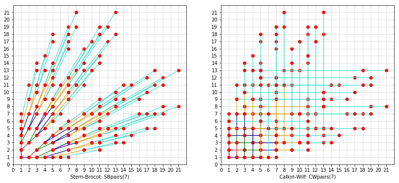

```python
#click to see  the code
xmax = 21
plt.rcParams["figure.figsize"] =  [14.0, 6.0]
fig = plt.figure()
sub1 = fig.add_subplot(1,2, 1)
tree = SBpairs(7)
for k in range(0,len(tree)-1):
    level_colors=['blue','brown','green','navy','goldenrod','turquoise']
    for i in range(len(tree[k])):
        pt = np.array(tree[k][i])
        pts = np.array([tree[k+1][2*i],tree[k+1][2*i+1]])
        plot_pt2pts(sub1,pt,pts,colors=[level_colors[k%len(level_colors)]])
        plot_points(sub1,pt.reshape(1,2))
        plot_points(sub1,pts)
gridticks(sub1,xmajticks=(0,xmax+1,1))
sub1.set_xlabel('Stern-Brocot: SBpairs(7)')

#plt.rcParams["figure.figsize"] =  [6.0, 14.0]
#fig = plt.figure()
sub4 = fig.add_subplot(1,2, 2)
tree = CWpairs(7)
for k in range(0,len(tree)-1):
    level_colors=['blue','brown','green','navy','goldenrod','turquoise']
    for i in range(len(tree[k])):
        pt = np.array(tree[k][i])
        pts = np.array([tree[k+1][2*i],tree[k+1][2*i+1]])
        plot_pt2pts(sub4,pt,pts,colors=[level_colors[k%len(level_colors)]])
        plot_points(sub4,pt.reshape(1,2))
        plot_points(sub4,pts)
gridticks(sub4,xmajticks=(0,xmax+1,1))
sub4.set_xlabel('Calkin-Wilf: CWpairs(7)')
plt.show()
```

We can put more nodes in the grid, plotting all the relatively prime integer's pairs present in the grid

```python
def rel_prime(a: int, b: int) -> bool:
    """ return True if a and b are relatively prime

    Args:
        a: int
        b: int
    Returns:
        True or False
    """
    if a == b == 1:
        return False
    return gcd(a,b) == 1
```

```python
rel_prime(3,8)
```

```
True
```

and adding more branches to the Stern-Brocot tree, plotting the branches linking a node to his father.  
We define easily a function `SBfather(frac)` returning the father node of a node `(n,d)`:

```python
def SBfather(frac: Union[Tuple[int, int], str]) -> Tuple[int, int]:
    # frac: Union[Tuple[int, int], Fraction[int, int], str]
    # -> Union[Tuple[int, int], Fraction[int, int]] type hint doesn't recognize Fraction
    """ find the father node of a Stern-Brocot node from the pair or fraction value or string fraction value

    Args:
        frac: a fraction as a tuple (numerator: int, denominator: int) as (3,8)
        or a string as '3/8' or a fraction as Fraction(3,8)
    Returns:
        the pair value of the father of frac if the frac parameter value was a pair
        the fraction value of the father of frac if the frac parameter value was a fraction or a string fraction
    """
    father = SBfrac(SBpath(frac)[:-1])
    if type(frac) is tuple:
        return father.numerator,father.denominator
    return father
```

```python
SBfather((3,8))
```

```
(2, 5)
```

```python
SBfather('3/8')
```

```
Fraction(2, 5)
```

or again with more branches plotting the branches linking a node to his left and right sons.

```python
def SBsons(frac: Union[Tuple[int, int], str]) -> Tuple[Tuple[int, int],Tuple[int, int]]:
    # frac: Union[Tuple[int, int], Fraction[int, int], str]
    # -> Union[Tuple[int, int], Fraction[int, int]] type hint doesn't recognize Fraction
    """ find the (left son, right son) nodes pair of a Stern-Brocot tree node

    Args:
        frac: a fraction as a tuple (numerator: int, denominator: int) as (3,8)
        or a string as '3/8' or a fraction as Fraction(3,8)
    Returns:
        a pair of pair's values for the sons of frac if the frac parameter value was a pair
        a pair of fraction values for the sons of frac if the frac parameter value was a fraction or a string
    """
    path = SBpath(frac)
    sons = [SBfrac(path + 'L'),SBfrac(path + 'R' )]
    if type(frac) is tuple:
        return ((sons[0].numerator,sons[0].denominator),(sons[1].numerator,sons[1].denominator))
    return sons
```

```python
SBsons((2, 5))
```

```
((3, 8), (3, 7))
```

In this case the sons can be out of the grid and we have to clip the lines.

```python
def xylinefrom(*pts: np.array) -> Tuple[Tuple[float,float],Tuple[float,float]]:
    """ compute 2 pairs (x0,x1),(y0,y1) to be plotted by matlib.plot

    Args:
        pts : a np.array of 2 or 3 points in the plane
        the 2 pts pts[0] and pts[1] verifying:
           0 < pts[0][0] < pts[1][0]
           0 < pts[0][1] < pts[1][1]
        if present, the third point defines a clipping
        window (0,xmax=pts[2][0]),(0,ymax=pts[2][1])
        to the segment defined by pts[0]to pts[1].
    Returns:
        two pairs (x0,x1),(y0,y1) defining the segment
        ready to be plotted by matlib.plot
    """
    xs = [pt[0] for pt in pts]
    ys = [pt[1] for pt in pts]
    if len(pts) == 2:
        return xs,ys
    else:
        m = (ys[1]-ys[0])/(xs[1]-xs[0])
        if xs[1] > xs[2]:
            xs[1] = xs[2]
            ys[1] = ys[0] + m*(xs[1]-xs[0])
        if ys[1] > ys[2]:
            ys[1] = ys[2]
            xs[1] = xs[0] + (xs[1]-xs[0])/m
    return xs[:2],ys[:2]
```

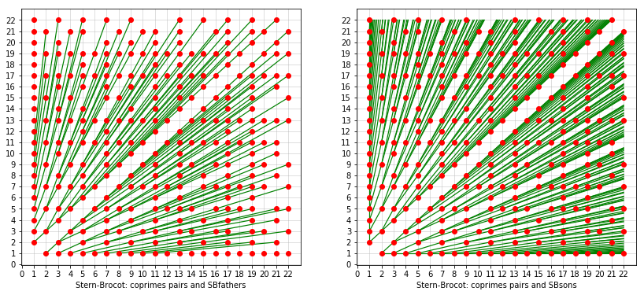

```python
#click to see the plot's code
xmax = 22
plt.rcParams["figure.figsize"] =  [14.0, 6.0]
fig = plt.figure()

sub2 = fig.add_subplot(1,2, 1)
for lin in range(2,xmax+1):
    xpts = [col for col in range(lin+1,xmax+1) if rel_prime(col,lin)]
    ypts = len(xpts)*[lin]
    for i in range(len(xpts)):
        xpair,ypair = np.array((SBfather((xpts[i],lin)),(xpts[i],lin))).T
        sub2.plot(xpair, ypair, color='green', linewidth=1.2)
        sub2.plot(ypair, xpair, color='green', linewidth=1.2)
for lin in range(1,xmax+1):
    xpts = [col for col in range(1,xmax+1) if rel_prime(col,lin)]
    ypts = len(xpts)*[lin]
    for i in range(len(xpts)):
        sub2.plot(xpts[i], ypts[i], color='red', marker='o')
gridticks(sub2,xmajticks=(0,xmax+1,1))
sub2.set_xlabel('Stern-Brocot: coprimes pairs and SBfathers')


#xmax = 22
#plt.rcParams["figure.figsize"] =  [6.0, 6.0]

sub3 = fig.add_subplot(1,2, 2)
for lin in range(1,xmax+1):
    xpts = [col for col in range(lin+1,xmax+1) if rel_prime(col,lin)]
    ypts = len(xpts)*[lin]
    for i in range(len(xpts)):
        left,right = SBsons((xpts[i],lin))
        #xpair,ypair = pts2xys(SBfather((xpts[i],lin)),(xpts[i],lin))
        xpair,ypair = xylinefrom((xpts[i],lin),left,(xmax,xmax))
        sub3.plot(xpair, ypair, color='green', linewidth=1.2)
        sub3.plot(ypair, xpair, color='green', linewidth=1.2)
        xpair,ypair = xylinefrom((xpts[i],lin),right,(xmax,xmax))
        sub3.plot(xpair, ypair, color='green', linewidth=1.2)
        sub3.plot(ypair, xpair, color='green', linewidth=1.2)
for lin in range(1,xmax+1):
    xpts = [col for col in range(1,xmax+1) if rel_prime(col,lin)]
    ypts = len(xpts)*[lin]
    for i in range(len(xpts)):
        sub3.plot(xpts[i], ypts[i], color='red', marker='o')
gridticks(sub3,xmajticks=(0,xmax+1,1))
sub3.set_xlabel('Stern-Brocot: coprimes pairs and SBsons')
plt.show()
```